# Relationship Between Duration of Ride With Other Characteristics of Trips

## by (Solomon Chikwendu)

## Investigation Overview

For the presentation, I focused on the influence of the customer type and gender on duration of trips

## Dataset Overview

The data consisted of duration and attributes of approximately 175,000 bike trips covering the greater San Francisco Bay area. The attributes included member gender, user type, start time, start station name, bike_share_for_all_trip etc. Eight thousand four hundred and fifty data points were removed from the analysis duue to missing information

## Distribution of Rides Duration

Rides within the range duration of 200 - 400 seconds are most common. The number of rides descreases as the duration of ride increase. The slight increase in the 1000 - 2000 duration is as a result of the increased group size from 200 to 1000.

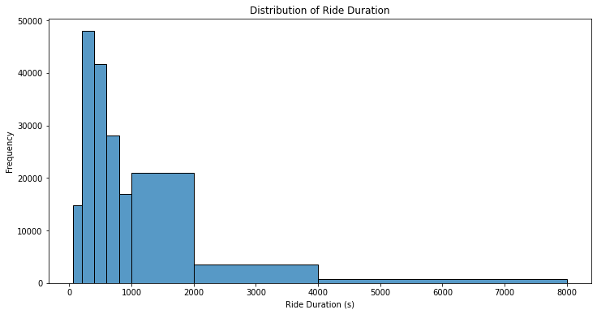

## Start Day vs Duration vs Gender

The chart shows that irrespective of the day, it takes lesser time for male to complete a ride compared to female and other gender. The duration of rides for male is almost the same during the week. We can also see the huge variances in duration for other gender which is highest on Sunday.

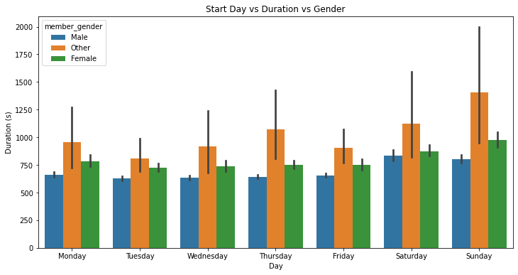

## Start Time

The higher ride frequencies for morning (8th and 9th hours) and evening (17th and 18th hours) can be linked to the rush hours where people are leaving for work and come later in the evening. Rides are usually low in the early hours of the morning between 12am to 5am. This could be because people are still asleep. Rides starts increasing from 6am till 8am which is the peak period.

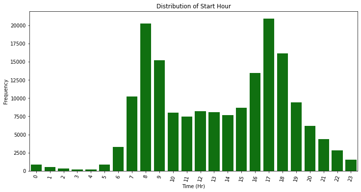